# Homework Code/Results

For MATH5000 by ctong

## Q1

##### **Q1. ACME’s CEO boasts that they have one of the highest paid sales force in the nation. He claims that average sales representative is paid over $28 per hour. Test this claim at a 10% level of significance.**

##### **[Step 1]** Is the variable of interest a scale variable or a categorical variable? Identify the null and alternative hypotheses. What are the relevant data assumptions?

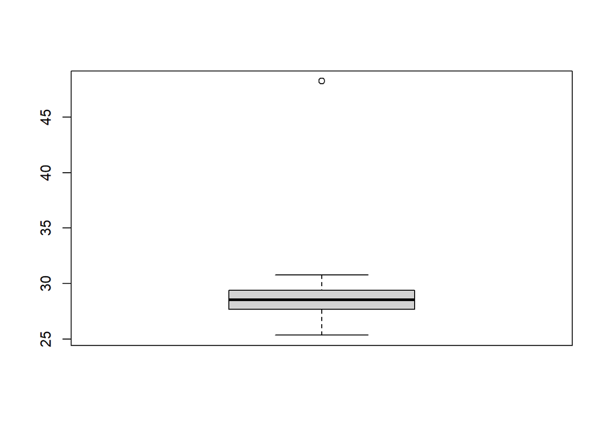

```r
df<-dfHR
hpOut<-boxplot(df$HrPay)$out
```

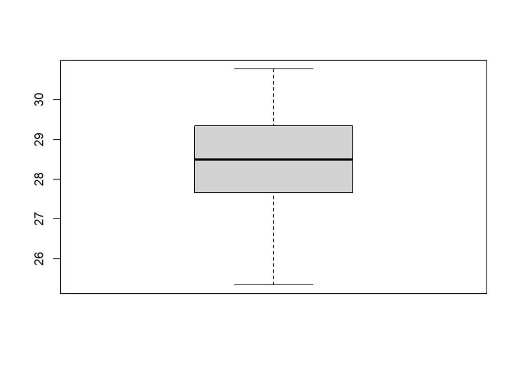

```r
df2<-df[!(df$HrPay %in% hpOut),]
boxplot(df2$HrPay)
```

##### **[Step 2]** How many outliers were removed?

```r
shapiro.test(df2$HrPay)
```

```
##
##  Shapiro-Wilk normality test
##
## data:  df2$HrPay
## W = 0.98675, p-value = 0.2987
```

##### **[Step 3]** Were the data assumptions met?

```r
describe(df2$HrPay)
```

```
##    vars   n  mean   sd median trimmed  mad   min   max range  skew kurtosis
## X1    1 119 28.46 1.17  28.49    28.5 1.25 25.34 30.77  5.43 -0.31    -0.34
##      se
## X1 0.11
```

##### **[Step 4]** Which ONE of the following analyses is appropriate for answering this question?

```r
t.test(df2$HrPay,mu=28, alternative="two.sided")
```

```
##
##  One Sample t-test
##
## data:  df2$HrPay
## t = 4.2726, df = 118, p-value = 3.934e-05
## alternative hypothesis: true mean is not equal to 28
## 95 percent confidence interval:
##  28.24509 28.66853
## sample estimates:
## mean of x
##  28.45681
```

```r
t.test(df2$HrPay,mu=28, alternative="less")
```

```
##
##  One Sample t-test
##
## data:  df2$HrPay
## t = 4.2726, df = 118, p-value = 1
## alternative hypothesis: true mean is less than 28
## 95 percent confidence interval:
##      -Inf 28.63406
## sample estimates:
## mean of x
##  28.45681
```

```r
t.test(df2$HrPay,mu=28, alternative="greater")
```

```
##
##  One Sample t-test
##
## data:  df2$HrPay
## t = 4.2726, df = 118, p-value = 1.967e-05
## alternative hypothesis: true mean is greater than 28
## 95 percent confidence interval:
##  28.27956      Inf
## sample estimates:
## mean of x
##  28.45681
```

```r
wilcox.test(df2$HrPay,mu=28, alternative="two.sided")
```

```
##
##  Wilcoxon signed rank test with continuity correction
##
## data:  df2$HrPay
## V = 5113.5, p-value = 4.281e-05
## alternative hypothesis: true location is not equal to 28
```

```r
wilcox.test(df2$HrPay,mu=28, alternative="less")
```

```
##
##  Wilcoxon signed rank test with continuity correction
##
## data:  df2$HrPay
## V = 5113.5, p-value = 1
## alternative hypothesis: true location is less than 28
```

```r
wilcox.test(df2$HrPay,mu=28, alternative="greater")
```

```
##
##  Wilcoxon signed rank test with continuity correction
##
## data:  df2$HrPay
## V = 5113.5, p-value = 2.14e-05
## alternative hypothesis: true location is greater than 28
```

##### **[Step 5]** Based on the results of the analysis that you selected in previous step, answer the question in plain language.

## Q2

##### **Q2. An internal HR report indicated that the sales representatives at ACME publishing claimed less than $3000 in benefits in the current year. Does the sample data support this claim?**

##### **[Step 1]** Is the variable of interest a scale variable or a categorical variable? Identify the null and alternative hypotheses. What are the relevant data assumptions?

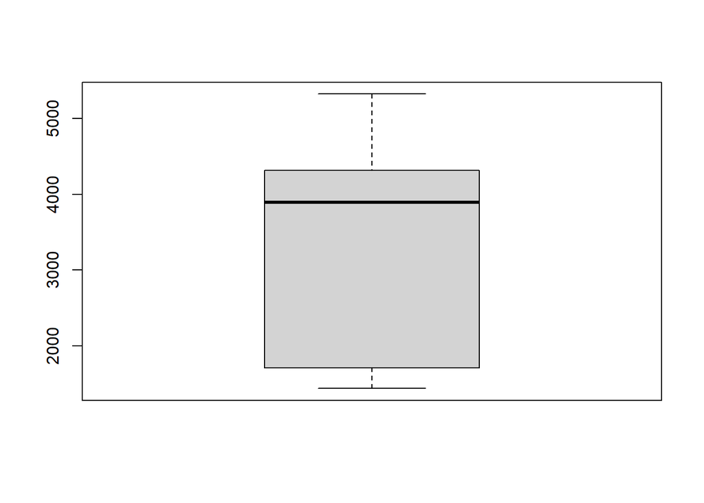

```r
df<-dfHR
ppOut<-boxplot(df$BeneCurr)$out
```

##### **[Step 2]** How many outliers were removed?

```r
describe(df$BeneCurr)
```

```
##    vars   n    mean      sd median trimmed     mad  min  max range  skew
## X1    1 120 3615.23 1329.41   3894 3672.22 1167.55 1438 5322  3884 -0.52
##    kurtosis     se
## X1    -1.04 121.36
```

```r
shapiro.test(df$BeneCurr)
```

```
##
##  Shapiro-Wilk normality test
##
## data:  df$BeneCurr
## W = 0.83864, p-value = 4.009e-10
```

##### **[Step 3]** Were the data assumptions met?

##### **[Step 4]** Which ONE of the following analyses is appropriate for answering this question?

```r
t.test(df$BeneCurr, mu = 3000, alternative="less")
```

```
##
##  One Sample t-test
##
## data:  df$BeneCurr
## t = 5.0696, df = 119, p-value = 1
## alternative hypothesis: true mean is less than 3000
## 95 percent confidence interval:
##      -Inf 3816.416
## sample estimates:
## mean of x
##  3615.233
```

```r
t.test(df$BeneCurr, mu = 3000, alternative="less")
```

```
##
##  One Sample t-test
##
## data:  df$BeneCurr
## t = 5.0696, df = 119, p-value = 1
## alternative hypothesis: true mean is less than 3000
## 95 percent confidence interval:
##      -Inf 3816.416
## sample estimates:
## mean of x
##  3615.233
```

```r
t.test(df$BeneCurr, mu = 3000, alternative="less")
```

```
##
##  One Sample t-test
##
## data:  df$BeneCurr
## t = 5.0696, df = 119, p-value = 1
## alternative hypothesis: true mean is less than 3000
## 95 percent confidence interval:
##      -Inf 3816.416
## sample estimates:
## mean of x
##  3615.233
```

```r
wilcox.test(df$BeneCurr, mu = 3000, alternative="less")
```

```
##
##  Wilcoxon signed rank test with continuity correction
##
## data:  df$BeneCurr
## V = 4910, p-value = 0.9996
## alternative hypothesis: true location is less than 3000
```

```r
wilcox.test(df$BeneCurr, mu = 3000, alternative="less")
```

```
##
##  Wilcoxon signed rank test with continuity correction
##
## data:  df$BeneCurr
## V = 4910, p-value = 0.9996
## alternative hypothesis: true location is less than 3000
```

```r
wilcox.test(df$BeneCurr, mu = 3000, alternative="less")
```

```
##
##  Wilcoxon signed rank test with continuity correction
##
## data:  df$BeneCurr
## V = 4910, p-value = 0.9996
## alternative hypothesis: true location is less than 3000
```

##### **[Step 5]** Based on the results of the analysis that you selected in previous step, answer the question in plain language.

## Q3

##### **Q3. In a recent company memo at ACME publishing, sales representatives were congratulated for their exceptional performance. The memo reported that over 10% of the sales representatives were awarded a bonus. Verify this claim using the sample data provided.**

##### **[Step 1]** Is the variable of interest a scale variable or a categorical variable? Identify the null and alternative hypotheses. What are the relevant data assumptions?

```r
df<-dfHR
actionCounts<-table(df$Action)
actionCounts
```

```
##
##  Bonus Mentor   None
##     13     20     87
```

```r
n = sum(actionCounts)
n
```

```
## [1] 120
```

```r
x = actionCounts["Bonus"]
```

##### **[Step 2]** Were the data assumptions met?

##### **[Step 3]** Which ONE of the following analyses is appropriate for answering this question?

```r
prop.test(x,n,p=.1, alternative = "two.sided", correct=FALSE)
```

```
##
##  1-sample proportions test without continuity correction
##
## data:  x out of n, null probability 0.1
## X-squared = 0.092593, df = 1, p-value = 0.7609
## alternative hypothesis: true p is not equal to 0.1
## 95 percent confidence interval:
##  0.06441141 0.17655360
## sample estimates:
##         p
## 0.1083333
```

```r
prop.test(x,n,p=.1, alternative = "greater", correct=FALSE)
```

```
##
##  1-sample proportions test without continuity correction
##
## data:  x out of n, null probability 0.1
## X-squared = 0.092593, df = 1, p-value = 0.3805
## alternative hypothesis: true p is greater than 0.1
## 95 percent confidence interval:
##  0.07001757 1.00000000
## sample estimates:
##         p
## 0.1083333
```

```r
prop.test(x,n,p=.1, alternative = "less", correct=FALSE)
```

```
##
##  1-sample proportions test without continuity correction
##
## data:  x out of n, null probability 0.1
## X-squared = 0.092593, df = 1, p-value = 0.6195
## alternative hypothesis: true p is less than 0.1
## 95 percent confidence interval:
##  0.0000000 0.1639209
## sample estimates:
##         p
## 0.1083333
```

```r
prop.test(x,n,p=.1, alternative = "two.sided", correct=TRUE)
```

```
##
##  1-sample proportions test with continuity correction
##
## data:  x out of n, null probability 0.1
## X-squared = 0.023148, df = 1, p-value = 0.8791
## alternative hypothesis: true p is not equal to 0.1
## 95 percent confidence interval:
##  0.06126046 0.18145453
## sample estimates:
##         p
## 0.1083333
```

```r
prop.test(x,n,p=.1, alternative = "greater", correct=TRUE)
```

```
##
##  1-sample proportions test with continuity correction
##
## data:  x out of n, null probability 0.1
## X-squared = 0.023148, df = 1, p-value = 0.4395
## alternative hypothesis: true p is greater than 0.1
## 95 percent confidence interval:
##  0.06670239 1.00000000
## sample estimates:
##         p
## 0.1083333
```

```r
prop.test(x,n,p=.1, alternative = "less", correct=TRUE)
```

```
##
##  1-sample proportions test with continuity correction
##
## data:  x out of n, null probability 0.1
## X-squared = 0.023148, df = 1, p-value = 0.5605
## alternative hypothesis: true p is less than 0.1
## 95 percent confidence interval:
##  0.0000000 0.1687353
## sample estimates:
##         p
## 0.1083333
```

```r
binom.test(x,n,p=.1, alternative = "two.sided")
```

```
##
##  Exact binomial test
##
## data:  x and n
## number of successes = 13, number of trials = 120, p-value = 0.76
## alternative hypothesis: true probability of success is not equal to 0.1
## 95 percent confidence interval:
##  0.05895831 0.17812744
## sample estimates:
## probability of success
##              0.1083333
```

```r
binom.test(x,n,p=.1, alternative = "greater")
```

```
##
##  Exact binomial test
##
## data:  x and n
## number of successes = 13, number of trials = 120, p-value = 0.4239
## alternative hypothesis: true probability of success is greater than 0.1
## 95 percent confidence interval:
##  0.06528052 1.00000000
## sample estimates:
## probability of success
##              0.1083333
```

```r
binom.test(x,n,p=.1, alternative = "less")
```

```
##
##  Exact binomial test
##
## data:  x and n
## number of successes = 13, number of trials = 120, p-value = 0.6873
## alternative hypothesis: true probability of success is less than 0.1
## 95 percent confidence interval:
##  0.0000000 0.1667118
## sample estimates:
## probability of success
##              0.1083333
```

##### **[Step 4]** Based on the results of the analysis that you selected in the previous step, answer the question in plain language.

## Q4

##### **Q4. One of the sales managers at ACME publishing believes that employees who received a bonus are unlikely to miss professional development workshops. She believes that among those who received a bonus, less than half missed the workshop. Does the sample data support this belief at an alpha level of .10?**

##### **[Step 1]** Is the variable of interest a scale variable or a categorical variable? Identify the null and alternative hypotheses. What are the relevant data assumptions?

```r
df<-subset(dfHR, dfHR$Action=="Bonus")
pdCounts<-table(df$ProfDev)
pdCounts
```

```
##
##  No Yes
##   7   6
```

```r
n = sum(pdCounts)
n
```

```
## [1] 13
```

```r
x = pdCounts["No"]
```

##### **[Step 2]** Were the data assumptions met?

##### **[Step 3]** Which ONE of the following analyses is appropriate for answering this question?

```r
prop.test(x,n, p=.5, alternative="two.sided", correct=FALSE)
```

```
##
##  1-sample proportions test without continuity correction
##
## data:  x out of n, null probability 0.5
## X-squared = 0.076923, df = 1, p-value = 0.7815
## alternative hypothesis: true p is not equal to 0.5
## 95 percent confidence interval:
##  0.2914380 0.7679393
## sample estimates:
##         p
## 0.5384615
```

```r
prop.test(x,n, p=.5, alternative="greater", correct=FALSE)
```

```
##
##  1-sample proportions test without continuity correction
##
## data:  x out of n, null probability 0.5
## X-squared = 0.076923, df = 1, p-value = 0.3908
## alternative hypothesis: true p is greater than 0.5
## 95 percent confidence interval:
##  0.3248196 1.0000000
## sample estimates:
##         p
## 0.5384615
```

```r
prop.test(x,n, p=.5, alternative="less", correct=FALSE)
```

```
##
##  1-sample proportions test without continuity correction
##
## data:  x out of n, null probability 0.5
## X-squared = 0.076923, df = 1, p-value = 0.6092
## alternative hypothesis: true p is less than 0.5
## 95 percent confidence interval:
##  0.0000000 0.7388522
## sample estimates:
##         p
## 0.5384615
```

```r
prop.test(x,n, p=.5, alternative="two.sided", correct=TRUE)
```

```
##
##  1-sample proportions test with continuity correction
##
## data:  x out of n, null probability 0.5
## X-squared = 0, df = 1, p-value = 1
## alternative hypothesis: true p is not equal to 0.5
## 95 percent confidence interval:
##  0.2612033 0.7959825
## sample estimates:
##         p
## 0.5384615
```

```r
prop.test(x,n, p=.5, alternative="greater", correct=TRUE)
```

```
##
##  1-sample proportions test with continuity correction
##
## data:  x out of n, null probability 0.5
## X-squared = 0, df = 1, p-value = 0.5
## alternative hypothesis: true p is greater than 0.5
## 95 percent confidence interval:
##  0.2924748 1.0000000
## sample estimates:
##         p
## 0.5384615
```

```r
prop.test(x,n, p=.5, alternative="less", correct=TRUE)
```

```
##
##  1-sample proportions test with continuity correction
##
## data:  x out of n, null probability 0.5
## X-squared = 0, df = 1, p-value = 0.5
## alternative hypothesis: true p is less than 0.5
## 95 percent confidence interval:
##  0.0000000 0.7691541
## sample estimates:
##         p
## 0.5384615
```

```r
binom.test(x,n,p=.5, alternative = "two.sided")
```

```
##
##  Exact binomial test
##
## data:  x and n
## number of successes = 7, number of trials = 13, p-value = 1
## alternative hypothesis: true probability of success is not equal to 0.5
## 95 percent confidence interval:
##  0.2513455 0.8077676
## sample estimates:
## probability of success
##              0.5384615
```

```r
binom.test(x,n,p=.5, alternative = "greater")
```

```
##
##  Exact binomial test
##
## data:  x and n
## number of successes = 7, number of trials = 13, p-value = 0.5
## alternative hypothesis: true probability of success is greater than 0.5
## 95 percent confidence interval:
##  0.287049 1.000000
## sample estimates:
## probability of success
##              0.5384615
```

```r
binom.test(x,n,p=.5, alternative = "less")
```

```
##
##  Exact binomial test
##
## data:  x and n
## number of successes = 7, number of trials = 13, p-value = 0.7095
## alternative hypothesis: true probability of success is less than 0.5
## 95 percent confidence interval:
##  0.0000000 0.7760446
## sample estimates:
## probability of success
##              0.5384615
```

##### **[Step 4]** Based on the results of the analysis that you selected in the previous step, answer the question in plain language.

## Q5

##### **Q5. An internal HR report claimed that last year’s performance ratings had an mean score of 7. Verify this claim using the sample data provided.**

##### **[Step 1]** Is the variable of interest a scale variable or a categorical variable? Identify the null and alternative hypotheses. What are the relevant data assumptions?

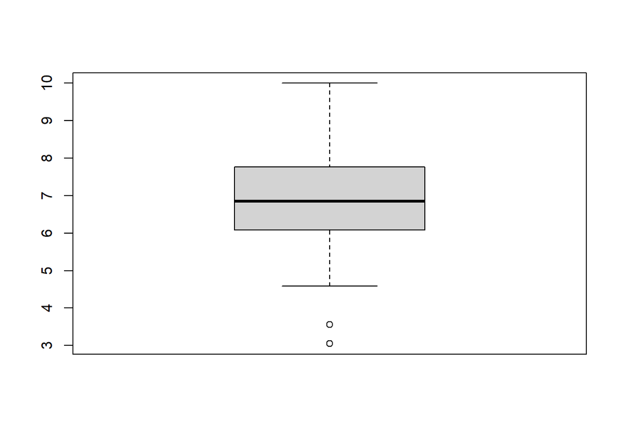

```r
df<-dfHR
ppOut<-boxplot(df$PerfPrev)$out
```

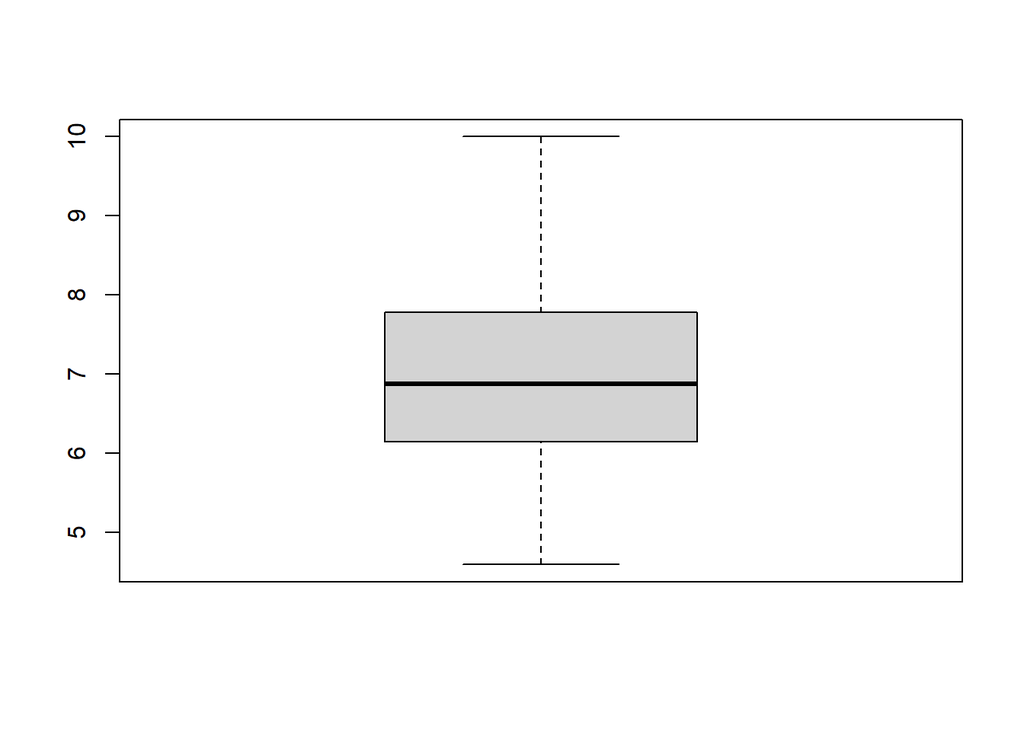

```r
df2<-df[!(df$PerfPrev %in% ppOut),]
boxplot(df2$PerfPrev)
```

##### **[Step 2]** How many outliers were removed?

```r
describe(df2$PerfPrev)
```

```
##    vars   n mean   sd median trimmed  mad  min max range skew kurtosis   se
## X1    1 118 6.99 1.22   6.87    6.96 1.25 4.59  10  5.41 0.21    -0.42 0.11
```

```r
shapiro.test(df2$PerfPrev)
```

```
##
##  Shapiro-Wilk normality test
##
## data:  df2$PerfPrev
## W = 0.98918, p-value = 0.4766
```

##### **[Step 3]** Were the data assumptions met?

##### **[Step 4]** Which ONE of the following analyses is appropriate for answering this question?

```r
t.test(df2$PerfPrev, mu = 7, alternative="two.sided")
```

```
##
##  One Sample t-test
##
## data:  df2$PerfPrev
## t = -0.065711, df = 117, p-value = 0.9477
## alternative hypothesis: true mean is not equal to 7
## 95 percent confidence interval:
##  6.770417 7.214837
## sample estimates:
## mean of x
##  6.992627
```

```r
t.test(df2$PerfPrev, mu = 7, alternative="greater")
```

```
##
##  One Sample t-test
##
## data:  df2$PerfPrev
## t = -0.065711, df = 117, p-value = 0.5261
## alternative hypothesis: true mean is greater than 7
## 95 percent confidence interval:
##  6.806599      Inf
## sample estimates:
## mean of x
##  6.992627
```

```r
t.test(df2$PerfPrev, mu = 7, alternative="less")
```

```
##
##  One Sample t-test
##
## data:  df2$PerfPrev
## t = -0.065711, df = 117, p-value = 0.4739
## alternative hypothesis: true mean is less than 7
## 95 percent confidence interval:
##      -Inf 7.178656
## sample estimates:
## mean of x
##  6.992627
```

```r
wilcox.test(df2$PerfPrev, mu = 7, alternative="two.sided")
```

```
##
##  Wilcoxon signed rank test with continuity correction
##
## data:  df2$PerfPrev
## V = 3420.5, p-value = 0.8101
## alternative hypothesis: true location is not equal to 7
```

```r
wilcox.test(df2$PerfPrev, mu = 7, alternative="greater")
```

```
##
##  Wilcoxon signed rank test with continuity correction
##
## data:  df2$PerfPrev
## V = 3420.5, p-value = 0.596
## alternative hypothesis: true location is greater than 7
```

```r
wilcox.test(df2$PerfPrev, mu = 7, alternative="less")
```

```
##
##  Wilcoxon signed rank test with continuity correction
##
## data:  df2$PerfPrev
## V = 3420.5, p-value = 0.405
## alternative hypothesis: true location is less than 7
```

##### **[Step 5]** Based on the results of the analysis that you selected in previous step, answer the question in plain language.